# HW08_Code_sol

**Machine Learning for Mechanical Engineering**  
**Homework 8**  
**Due Monday, 05/28/2018, 9:30 AM**

|  | by Prof. Seungchul Lee Industrial AI Lab POSTECH |
| --- | --- |

- For your handwritten solution, hand in your hardcopy at class.
- For your code, email your .ipynb file to (`iai.postech@gmail.com`)
- When you send an e-mail, write down [Machine Learning HW8] on the title
- And please write your NAME on your .ipynb files. ex) 김지원_20182315_HW8.ipynb
- Do not submit a printed version of your code. It will not be graded.

## Problem 1

The uniform distribution for a continuous variable $x$ is defined by

$$U(x;a,b) = \frac{1}{b-a}, \quad a\leq x \leq b$$

Verify that this distribution is normalized, and find expressions for its mean and variance.

## Problem 2

Consider two urns. The first contains two white and seven black balls, and the second contains five white and six black balls. We flip a fair coin and then draw a ball from the first urn or the second urn depending on whether the outcome was heads or tails. What is the conditional probability that the outcome of the toss was heads given that a white ball was selected?

## Problem 3

Suppose that $p(x,y)$, the joint probability mass function of $X$ and $Y$, is given by

$$p(1,1)=0.5, \quad p(1,2)=0.1, \quad p(2,1) = 0.1, \quad p(2,2)=0.3$$

Calculate the conditional probability mass function of $X$ given that $Y=1$.

## Problem 4

A and B go target shooting together. Both shoot at a target at the same time. Suppose A hits the target with probability 0.7, whereas B, independently, hits the target with probability 0.4.

(a) Given that exactly one shot hits the target, what is the probability that it was B's shot?

(b) Given that the target is hit, what is the probability that B hits it?

## Problem 5

Suppose that the two variables $x$ and $y$ are statistically independent. Show that the mean and variance of their sum satisfies

$$ \begin{align*} E[x+y] &= E[x]+E[y] \\ \text{var}(x+y) &= \text{var}(x) + \text{var}(y) \end{align*}$$

## Problem 6

A die is rolled twice. Let $X$ equal the sum of the outcomes, and let $Y$ equal the first outcome minus the second. Compute $\text{cov}(X,Y)$.

## Problem 7

Write a python code to find a linear transformation $y = Ax$ such that $y$ are uncorrelated (or independent), and plot the data after transformation.

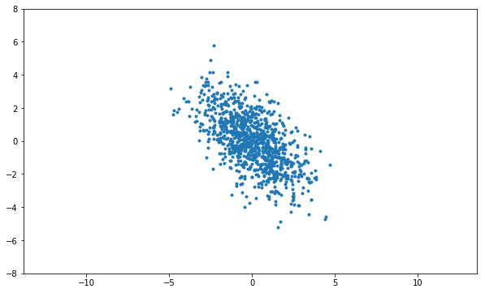

```python
import numpy as np
import matplotlib.pyplot as plt
%matplotlib inline

mu = np.array([0, 0])
sigma = 1./2.*np.array([[5, -3], [-3, 5]])

m = 1000
x = np.random.multivariate_normal(mu, sigma, m)

plt.figure(figsize=(10,6))
plt.plot(x[:,0], x[:,1], '.')
plt.axis('equal')
plt.ylim([-8,8])
plt.show()
```

```
[4.1250815  1.01824558]
[[ 0.69382666 -0.72014204]
 [-0.72014204 -0.69382666]]
```

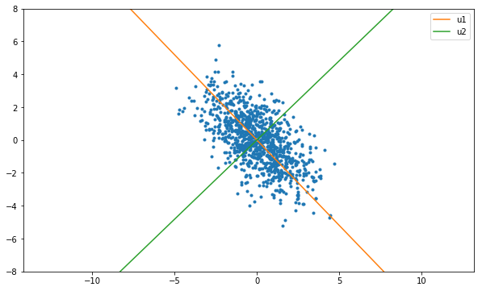

```python
X = np.asmatrix(x)

S = 1/(m-1)*X.T*X
S = np.asmatrix(S)

D, U = np.linalg.eig(S)

idx = np.argsort(-D)
D = D[idx]
U = U[:,idx]

print(D)
print(U)

xp = np.arange(-10, 10)

plt.figure(figsize=(10,6))
plt.plot(X[:,0],X[:,1],'.')
plt.plot(xp, U[1,0]/U[0,0]*xp, label='u1')
plt.plot(xp, U[1,1]/U[0,1]*xp, label='u2')
plt.axis('equal')
plt.ylim([-8, 8])
plt.legend()
plt.show()
```

```
[4.1250815  1.01824558]
[[ 1. -0.]
 [ 0.  1.]]
```

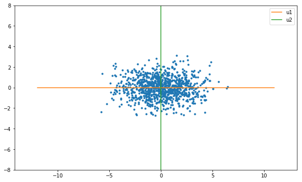

```python
Y = X*U

Sy = 1/(m-1)*Y.T*Y
Sy = np.asmatrix(Sy)

Dy, Uy = np.linalg.eig(Sy)

idx = np.argsort(-Dy)
Dy = Dy[idx]
Uy = Uy[:,idx]

np.set_printoptions(suppress=True)
print(Dy)
print(Uy)

yp = np.arange(-12, 12)

plt.figure(figsize=(10,6))
plt.plot(Y[:,0],Y[:,1],'.')
plt.plot(yp, Uy[1,0]/Uy[0,0]*yp, label='u1')
plt.plot(yp, Uy[1,1]/Uy[0,1]*yp, label='u2')
plt.axis('equal')
plt.ylim([-8, 8])
plt.legend()
plt.show()
```